# Air Quality and Respiratory Health: An Analysis on Healthcare System Loading

6it Consultants

8 June 2026

## Problem Introduction

- Air pollution is a major public health issue causing respiratory problems leading to increased hospital admissions
- We will explore data on air pollution levels and hospital admissions in 8 major cities across 2020–2025
- This presentation will examine how air pollution has affected hospital intakes in the years 2020-2025

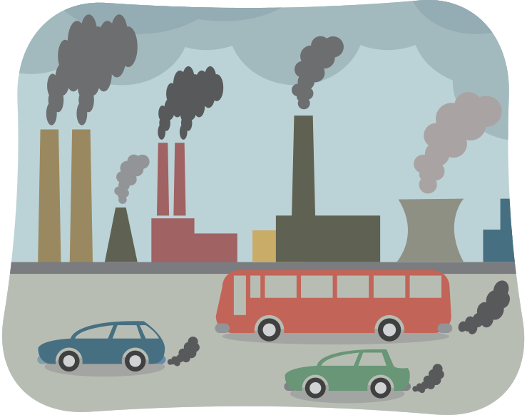

Credit: Thoracic and Sleep Group

## Dataset Exploration

- The dataset contained daily air quality and healthcare observations from eight cities between 2020 and 2025.
- Key variables included: `Air Quality Index (AQI)`, `PM2.5`, `PM10`, `NO2`, `O3`, `temperature`, `humidity`, `hospital admissions`, and `hospital capacity`.
- Daily observations were aggregated into monthly summaries and then yearly summaries to reduce short-term fluctuations and improve trend interpretation.

## Methodology

The analysis was conducted using R and several packages from the `tidyverse` (Wickham 2023) ecosystem for data cleaning, transformation, modelling, and visualisation.

The following ibraries were used:

- `lubridate` (Spinu et al. 2024) for date manipulation
- `ggplot2` (Wickham et al. 2025) for data visualisation
- `patchwork` (Pedersen 2025) for combining multiple plots
- `kableExtra` (Zhu 2024) for enhanced table formatting
- `broom` (Robinson et al. 2025) for tidying regression outputs
- `here` (Müller 2025) for reproducible file paths

## Regression

Table 1: Linear Regression Results for Hospital Admissions

| Variable | Coefficient | Standard Error | t value | p value |
| --- | --- | --- | --- | --- |
| (Intercept) | 4.6259 | 0.0690 | 67.0640 | 0.0000 |
| aqi | 0.0000 | 0.0001 | -0.4958 | 0.6201 |
| pm2_5 | 0.0987 | 0.0008 | 126.8675 | 0.0000 |
| pm10 | 0.0001 | 0.0006 | 0.1871 | 0.8516 |
| no2 | -0.0002 | 0.0012 | -0.2097 | 0.8339 |
| o3 | -0.0008 | 0.0010 | -0.8814 | 0.3781 |

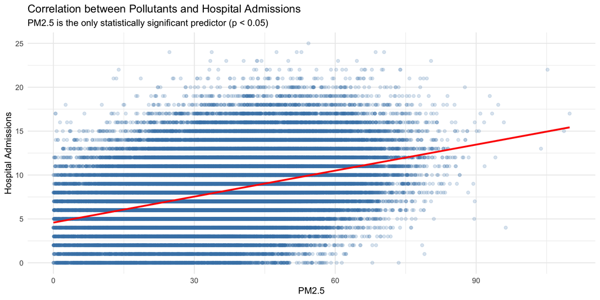

Figure 1: Correlation between Pollutants and Hospital Admissions

The regression analysis revealed that `PM2.5` levels were significantly positively associated with `hospital admissions` (p < 0.05), while other pollutants did not show a statistically significant relationship.

## Results

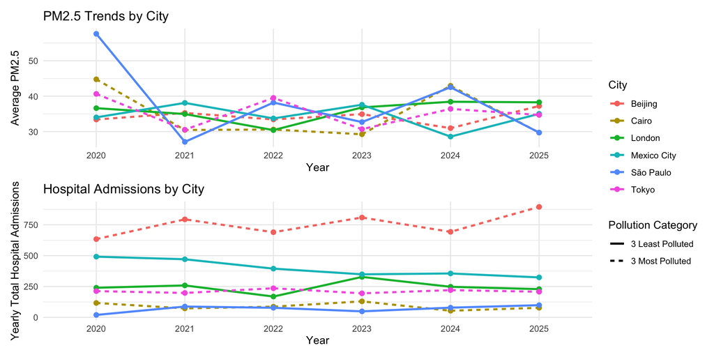

## Limitations

- First, the dataset only included a limited number of cities (8), reducing the ability to generalise findings globally. The data does not carry data prior to 2020, which makes it difficult to establish a pre-Covid baseline for both hospital admissions and air quality metrics.
- Second, hospital admissions may also be influenced by factors not included in the analysis, such as population size and density, healthcare accessibility, socioeconomic conditions, smoking prevalence, and public health policies.
- Third, yearly aggregation may hide short-term pollution spikes and seasonal health impacts.
- Fourth, the dataset has been taken at the courtesy of the [Kaggle](https://www.kaggle.com/datasets/tfisthis/global-air-quality-and-respiratory-health-outcomes) platform and hence cannot be relied to make any real-world conclusions or predictive analysis, based on the findings. It has been used solely for illustrative purposes and to build understanding of the health environment.

## Recommendation

- Governments should strengthen environmental regulations aimed at reducing PM2.5 emissions from traffic, industrial activities, and urban pollution sources.
- Healthcare systems in highly polluted cities should improve hospital preparedness and respiratory healthcare capacity.
- Future studies should include additional variables, such as population density, healthcare access, and socioeconomic conditions to improve analysis accuracy.
- Future investigation should take a more longitudinal approach, to better understand the impacts of Covid, and its associated lockdowns, on both air quality and hospital admissions, and to establish a clearer pre-Covid baseline.
- Future research using daily or seasonal data may provide deeper insight into short-term pollution impacts on respiratory health.
- Public awareness campaigns should encourage protective measures during periods of poor air quality.

## References

Müller, Kirill. 2025. *Here: A Simpler Way to Find Your Files*. https://here.r-lib.org/.

Pedersen, Thomas Lin. 2025. *Patchwork: The Composer of Plots*. https://patchwork.data-imaginist.com.

Robinson, David, Alex Hayes, and Simon Couch. 2025. *Broom: Convert Statistical Objects into Tidy Tibbles*. https://broom.tidymodels.org/.

Spinu, Vitalie, Garrett Grolemund, and Hadley Wickham. 2024. *Lubridate: Make Dealing with Dates a Little Easier*. https://lubridate.tidyverse.org.

Wickham, Hadley. 2023. *Tidyverse: Easily Install and Load the Tidyverse*. https://tidyverse.tidyverse.org.

Wickham, Hadley, Winston Chang, Lionel Henry, et al. 2025. *Ggplot2: Create Elegant Data Visualisations Using the Grammar of Graphics*. https://ggplot2.tidyverse.org.

Zhu, Hao. 2024. *kableExtra: Construct Complex Table with Kable and Pipe Syntax*. http://haozhu233.github.io/kableExtra/.